# Functionalizing NEON raster data

Sarah Graves

June 21, 2016

# Ojbectives

Start by putting up objectives/tasks that students will be working though:

1. **Import** a raster — A lidar canopy height model (lidar/Teak_lidarCHM.tif)
2. For the CHM, **set values** == 0 to NA (not trees)
3. **Visualize** density and plot vertical cutoff lines.
4. **Classify** the raster according to some distribution – low medium and tall trees. This could be done using a histogram potentially or we could just decide that <2m is generally grasses / understory, <6m small trees,and the rest are tall trees. A function could import the desired thresholds. Visualize histogram/density and plot vertical cutoff lines. (http://neon-workwithdata.github.io/neon-data-institute-2016/R/create-hillshade-R/)
5. **Plot** the classified raster, add a legend for each “class” - legends are super tricky to simplifying this process with a function would be good. see: http://neon-workwithdata.github.io/neon-data-institute-2016/R/classify-by-threshold-R/ for my take on forcing a legend outside of the plot area using par settings. You may have other better forms of magic to make this work well. :)
6. **Export** the plot figure to a pdf – publishable
7. **Export** the classified raster as a geotiff with NaFlagg = -9999 to an outputs folder.

# Load packages

```r
rm(list = ls())

library(raster)

source("scripts/functions.R")
```

# Import raster

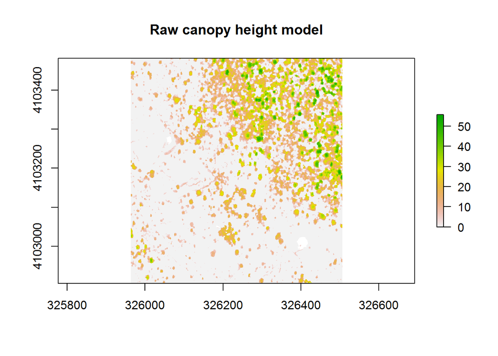

```r
chm_file <- "../NEONdata/D17-California/TEAK/2013/lidar/TEAK_lidarCHM.tif"
chm <- raster(chm_file)
plot(chm,
     main="Raw canopy height model")
```

```r
breaks <- c(5,10,20,100)
```

# Set NA values

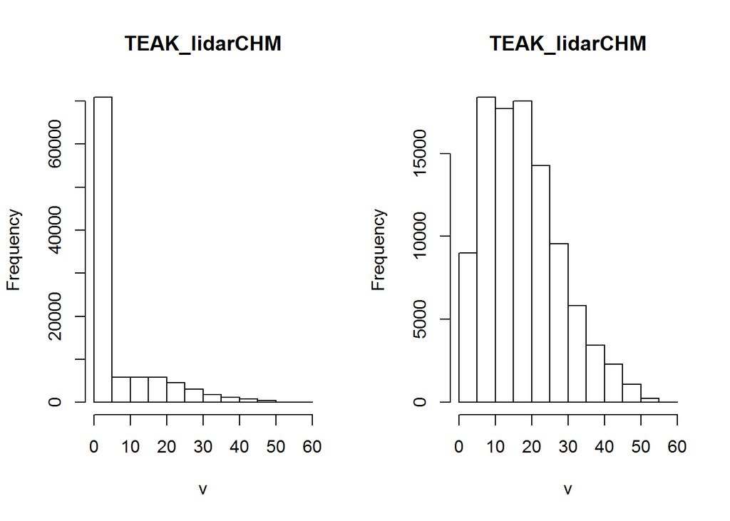

```r
par(mfrow=c(1,2))

hist(chm)
# assign NA to zeros because we don't want to analyze zero values (it's not vegetation)
chm[chm==0] <- NA

# check to see if zeros are removed
hist(chm)
```

```r
par(mfrow=c(1,1))
```

# Set class breaks and classify raster

```r
rcl.m <- create_ht_class_matrix(breaks)
```

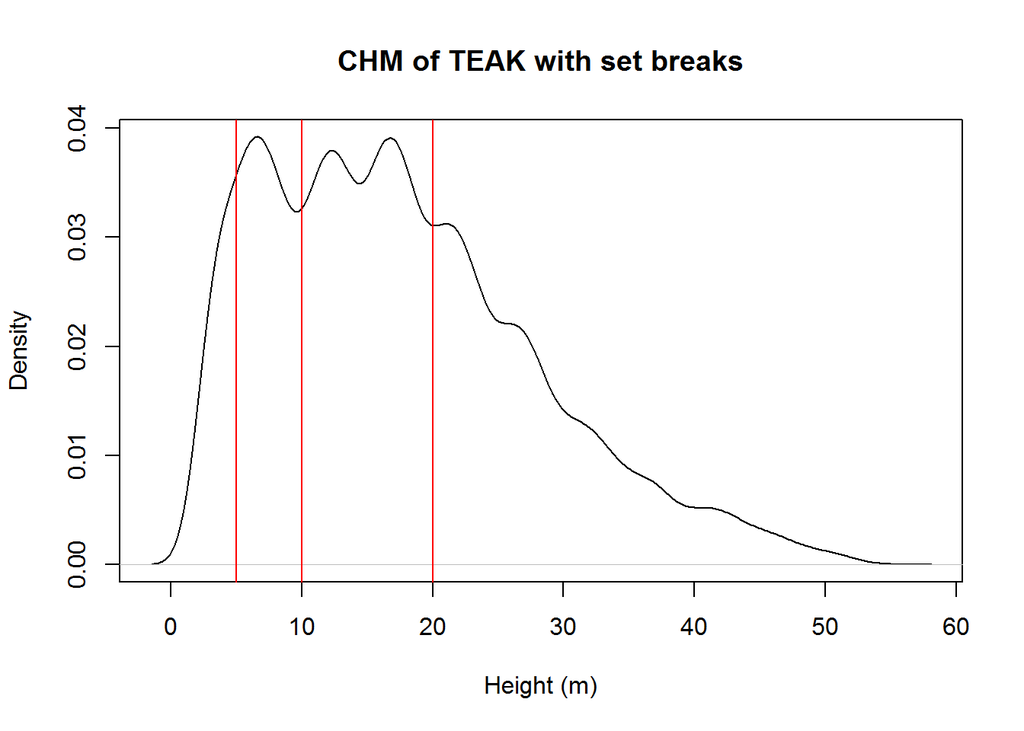

```r
plot_chm_dens(chm,title="CHM of TEAK with set breaks",breaks)
```

```r
make_pdf(plot_chm_dens(chm,title="CHM of TEAK with set breaks",breaks),
         filename = "TEAK CHM density with breaks2.pdf",
         width=7,height=6)
```

```
## Creating: TEAK CHM density with breaks2.pdf
```

# Classify raster

```r
# reclassify the raster using the reclass object - rcl.m
chm.class <- reclassify(chm,
                        rcl.m)
```

# Plot classified raster

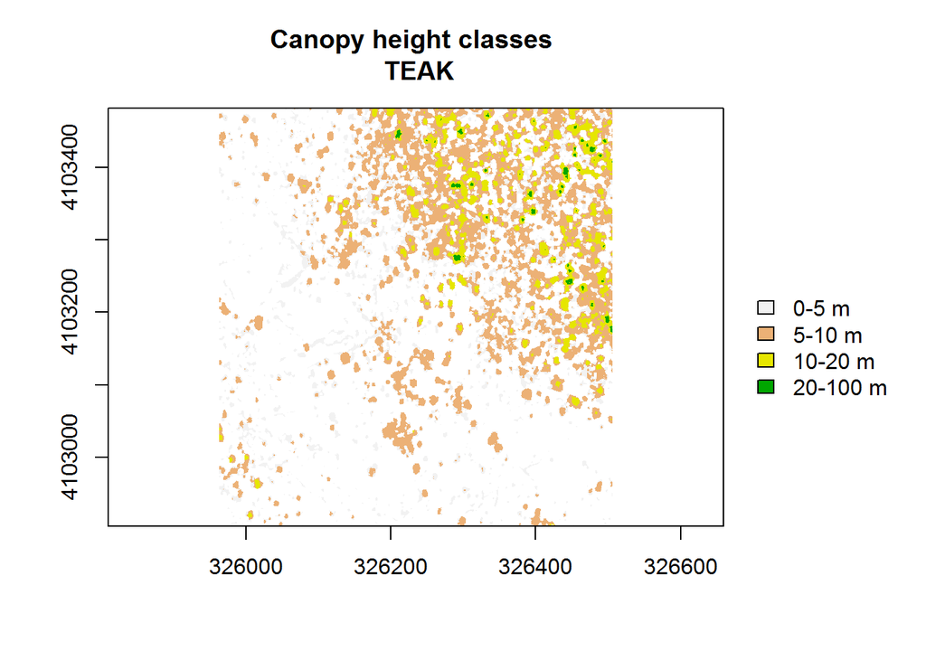

```r
plot_reclassified_raster(chm,"TEAK",breaks)
```

# Export classified raster to GeoTiff

```r
writeRaster(chm.class,"../outputs/TEAK/TEAK_chm_classified.tif",
            format="GTiff",
            NAflag=-9999,
            overwrite=T)
```